# Case 1 ‘CALUX’

2017-05-17

## Directions

*Use ggplot syntaxis for all the figures in this case study.*

*Use this Rmarkdown template to create a report adressing the assignment below. The Rmd template can be found in the folder: //home/../cases/*

## Introduction

For the assessment of carcinogenic potential of chemicals, animal testing required. Recently, we have performed a ring trial with two laboratories to acertain the predictive capacity of a reporter cell line to accurately classify chemicals on the basis of reporter signal (fluorescence).

## The case assignment

1. Create a github repository “case_1_calux” in your account.
2. Read the data into R
3. Inspect the data
4. Describe mising values and the type of variables
5. Generate at least 4 different graphs that describe the data.
6. Answer the case questions below.
7. Upload a rendered (github_document) and the Rmd file to you github account
8. Sent the teacher an email with the link to the files

## **TIPs**

- For this case you need to know about importing data in R. The file is csv format, remember to set the `na.strings`. Determine the delimiter used in the datafile. You can open the file in a text editor.
- Remember the programming rules: use `snake_case` fore all variables in the data and in your script.
- Use the syntax from the {tidyverse} as much a possible
- You are allowed to use google/stack overflow, whatever you can find to solve the questions
- All graphics must be made with {ggplot2}
- Remember {dplyr} to `select()`, `filter()`, `group_by()`, `mutate()` and `summarize()` data
- Check the type of each variable in the data. Do you need to change the variable type like `data$var_1 <- as.factor(data$var_1)`?

## Case questions

Try to answer the next 4 questions:

Graph 1) How does the relationship between the chemicals (`$name`) and the `$p53_cyto_mec` variable look?

Graph 2) Can you plot the relationships between the `$class` variable and the `$p53.ifmax` variable for each `$laboratory`?

Graph 3) Make a graph with facets that display only chemical sthat have an induction of mean `p53.ifmax` of above 5.0.

Graph 4) Create a meaningful bar-graph for this data set. You can choose what to plot yourself

## Review criteria

- Your code must provide the steps above in such a way that someone else can understand the code.
- Provide a clear description of what your code does
- Describe the graphs in your report.
- Provide the complete code in a rendered Rmd (to HTML) file

## Case data

Load the data from the data folder “//root/data/case_1_calux/”

This folder contains two files:

*variables_calux.md* and *zonmw_calux_all_data.csv*

The data for this case is in the file “zomw_calux_all_data.csv”

You need to change the names of the variables to the “conventions” (e.g. `$p53_cyto_mec`) do this first after loading the data.

```r
library(tidyverse)
data_path <- file.path(root, "data", "case_1_calux", "zonmw_calux_all_data.csv")
prevalidation <- read_delim(data_path,
    na = "NA", delim = ";")
```

## Adding row_id

Remember “Data management” it is good idea to add a row id

## Change names of variables

## Case question that will help you create the above 4 graphs:

## 1) Geoms

The chemicals tested were divided into 3 classes. This graph is about showing the realtionship btween the chemicals and the induction of p53. Can you think of a way to convey this information in a plot? What type or types of `geom_` will you use?

## 2) The variables in the data

Which variable types are represented in the data. You can find more information in the “variables_calux.md” file. Change the type of the variable if necessary.

## 3) Complete cases

The dataset has a number of missing values and incomplete cases. First filter the data for all the cases that are complete

## 3) Summarize data

Do you need to calculate means for every chemical? In oder to investigate relations it is probably a good idea to calculate the mean of the duplos (you can see two observations for most chemical). Calculate a summary where you `group_by(laboratory, name, nr, class, s9_mix)` Use this summary for graph 2-4.

## Example plot 1:

How does the relationship between the chemicals (`$name`) and the `$p53_cyto_mec` variable look?

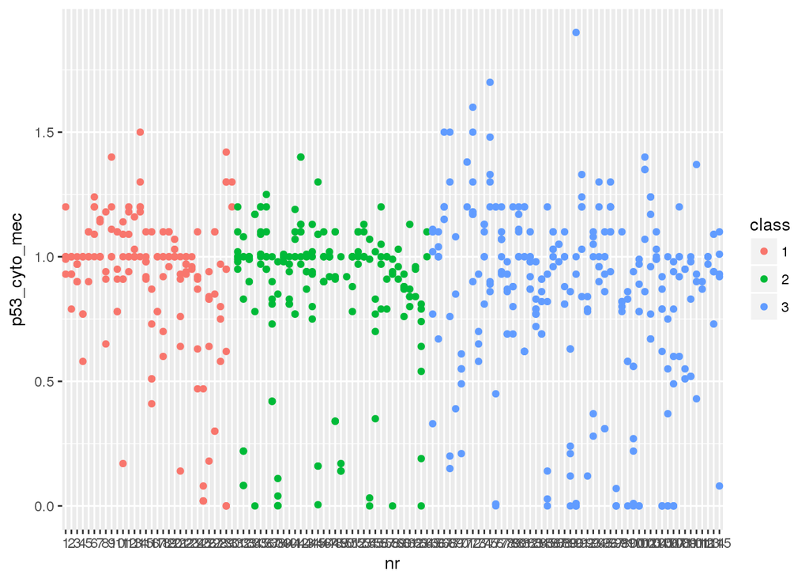

## Example plot 2:

Can you plot the relationships between the `$name`, the `$class` variable and the `$p53.ifmax` variable for each `$laboratory`? Make this plot from summarized data (sumarize the observation for each duplo measurement)

[figure not shown]

## Another example

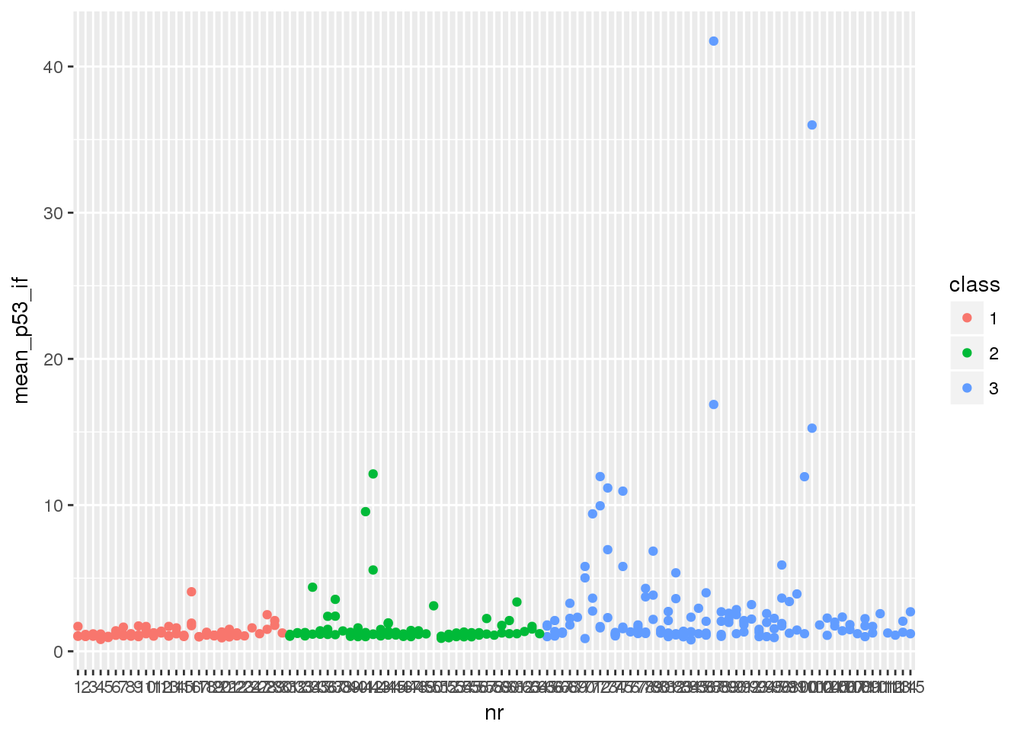

## Example graph 3

Make a graph with facets that display only the chemical that have an induction of mean p53_if of above 5.0.

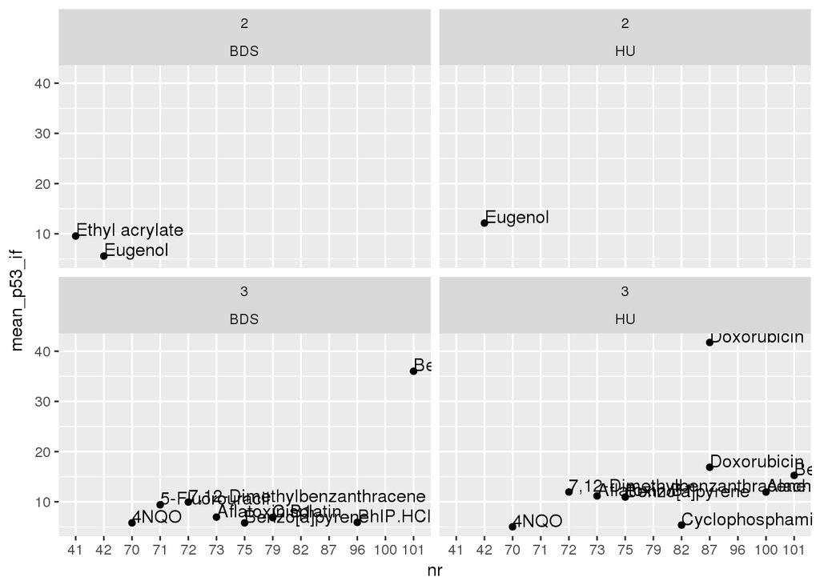

What can you conclude from this plot on the relation between class of the chemical and the induction of p53_if_max?

Example graph 4 Create a meaningful bar-graph for this data set. You can choose what to plot yourself See e.g. page 29 from “r4ds”

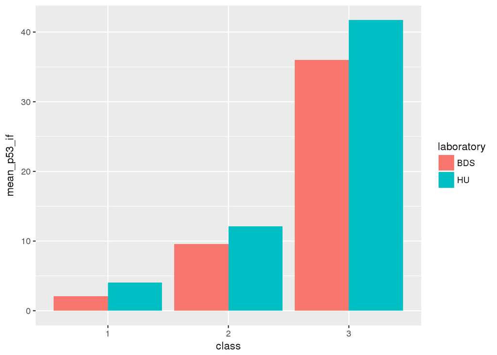